# Análisis Estadistico de obesidad de niños y niñas de 6 a 9 años

Leyendo la base de datos de mediciones. El IMC es El índice de masa corporal es una razón matemática que asocia la masa y la talla de un individuo. Vamos a sacar la estructura de datos

## Clasificación de datos

Estado -> Dato cualitativo, Nominal

Sexo -> Dato cualitativo, Nominal

Edad -> Dato cuantitativo discreto

porcentajegrasa -> Dato cuantitativo continuo

Cintura -> Dato cuantitativo continuo

Estatura -> Dato cuantitativo continuo

Peso -> Dato cuantitativo continuo

IMC -> Dato cuantitativo continuo

```r
mediciones<-read.csv("mediciones.csv", as.is = FALSE)
				str(mediciones)
```

```
## 'data.frame':    18581 obs. of  8 variables:
					##  $ estado         : Factor w/ 32 levels "AGUASCALIENTES",..: 20 20 20 20 20 20 20 20 5 27 ...
					##  $ sexo           : Factor w/ 2 levels "Hombre","Mujer": 2 2 2 2 2 2 2 2 1 2 ...
					##  $ edad           : int  16 16 16 16 16 16 16 16 16 16 ...
					##  $ porcentajegrasa: int  13 18 18 7 20 38 18 38 34 25 ...
					##  $ cintura        : int  58 63 60 75 58 98 63 85 90 63 ...
					##  $ estatura       : num  1.52 1.52 1.54 1.6 1.52 1.57 1.56 1.63 1.76 1.64 ...
					##  $ peso           : num  54.9 54.9 54.9 54.9 54.9 ...
				##  $ imc            : num  23.8 23.8 23.1 21.4 23.8 ...
```

## Creando los subconjuntos

Primer subconjunto 6 a 9 años

```r
attach(mediciones)
					filtro = subset(mediciones, edad %in% c(6,7,8,9),select=estado:imc)
				detach (mediciones)
```

## Sacando el rango

```r
range(filtro$edad)
```

```
## [1] 6 9
```

## Sacando la frecuencia por estado

```r
summary(filtro$estado)
```

```
##        AGUASCALIENTES BAJA CALIFORNIA NORTE   BAJA CALIFORNIA SUR
		##                    28                    19                    46
		##              CAMPECHE               CHIAPAS             CHIHUAHUA
		##                     0                   638                    30
		##      CIUDAD DE MEXICO              COAHUILA                COLIMA
		##                    35                    13                    25
		##               DURANGO            GUANAJUATO              GUERRERO
		##                   115                    79                     8
		##               HIDALGO               JALISCO                MEXICO
		##                   487                    14                   683
		##             MICHOACAN               MORELOS               NAYARIT
		##                   176                   300                    53
		##            NUEVO LEON                OAXACA                PUEBLA
		##                    97                   450                   612
		##             QUERETARO          QUINTANA ROO       SAN LUIS POTOSI
		##                    61                    38                    26
		##               SINALOA                SONORA               TABASCO
		##                    41                   156                    23
		##            TAMAULIPAS              TLAXCALA              VERACRUZ
		##                    46                    11                   184
		##               YUCATAN             ZACATECAS
	##                    32                   210
```

## Los 8 estados

```r
attach(filtro)
		dftf = subset(filtro, estado %in% c("OAXACA","MEXICO","ZACATECAS","MORELOS","CHIAPAS","HIDALGO","PUEBLA","VERACRUZ"),select=estado:imc)
		dftf$estado <- factor(dftf$estado)
	summary(dftf)
```

```
##      estado        sexo           edad       porcentajegrasa    cintura
		##  MEXICO :683   Hombre:1750   Min.   :6.000   Min.   : 7.00   Min.   :  7.00
		##  CHIAPAS:638   Mujer :1814   1st Qu.:7.000   1st Qu.:16.00   1st Qu.: 55.00
		##  PUEBLA :612                 Median :8.000   Median :20.00   Median : 59.00
		##  HIDALGO:487                 Mean   :7.839   Mean   :20.03   Mean   : 59.65
		##  OAXACA :450                 3rd Qu.:9.000   3rd Qu.:24.00   3rd Qu.: 65.00
		##  MORELOS:300                 Max.   :9.000   Max.   :45.00   Max.   :100.00
		##  (Other):394
		##     estatura         peso            imc
		##  Min.   :0.90   Min.   :15.00   Min.   : 7.23
		##  1st Qu.:1.21   1st Qu.:23.00   1st Qu.:15.12
		##  Median :1.27   Median :27.00   Median :16.46
		##  Mean   :1.27   Mean   :27.80   Mean   :17.06
		##  3rd Qu.:1.33   3rd Qu.:31.76   3rd Qu.:18.56
		##  Max.   :1.60   Max.   :80.00   Max.   :66.12
	##
```

```r
attach(dftf)
```

## Vamos a hacer la grafica redonda

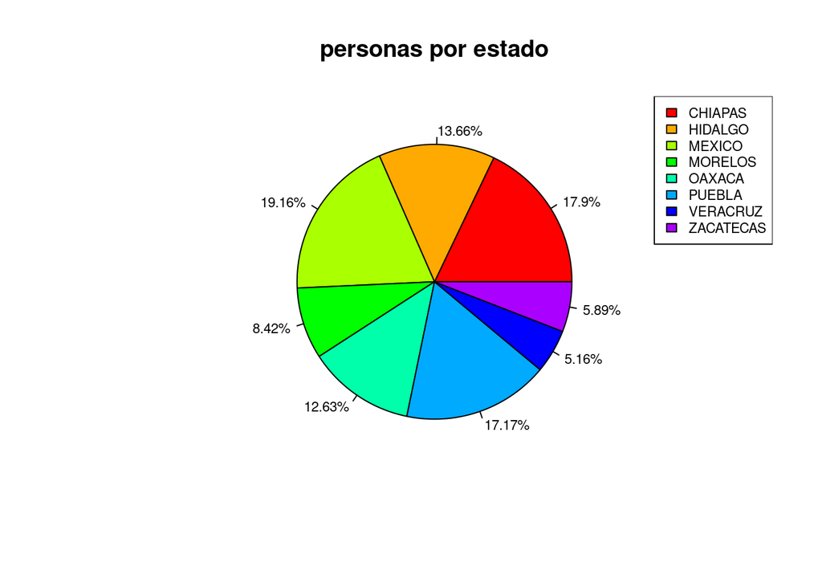

```r
cil=table(estado)
	porcentaje=prop.table(cil)
	etiquetas=paste(round(porcentaje*100,2),"%",sep="")
	pie(cil,main="personas por estado",col=rainbow(9),
	    labels=etiquetas, cex=0.7)
	legend("topright",rownames(cil),fill=rainbow(9),
cex=0.7)
```

## Haciendo la gráfica de barras del estado por sexo

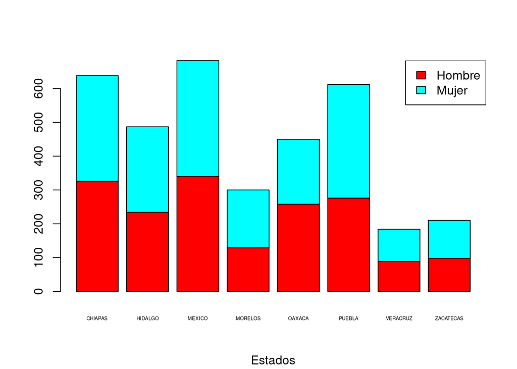

```r
gen=table(sexo, estado)
	barplot(gen, col=rainbow(2), sub = "Estados", cex.names = 0.4)
legend("topright",rownames(gen),fill=rainbow(2), cex =1)
```

## Tabulacion cruzada por estado y edad

```r
table(estado, edad)
```

```
##            edad
## estado        6   7   8   9
##   CHIAPAS    67  65 230 276
##   HIDALGO   121 104 120 142
##   MEXICO    123 162 163 235
##   MORELOS    54  77 102  67
##   OAXACA     29  59  88 274
##   PUEBLA    137 162 215  98
##   VERACRUZ   15  22  29 118
##   ZACATECAS  32  47  60  71
```

## Frecuencias absolutas y porcentuales para sexo y edad

```r
table(sexo, edad)
```

```
##         edad
## sexo       6   7   8   9
##   Hombre 287 341 505 617
##   Mujer  291 357 502 664
```

```r
cumsum(table(sexo,edad))
```

```
## [1]  287  578  919 1276 1781 2283 2900 3564
```

## Frecuencia porcentual

```r
prop.table(table(sexo,edad))*100
```

```
##         edad
## sexo             6         7         8         9
##   Hombre  8.052750  9.567901 14.169473 17.312009
##   Mujer   8.164983 10.016835 14.085297 18.630752
```

## Crear un bloxplot sobre grasa corporal entre hombres y mujeres

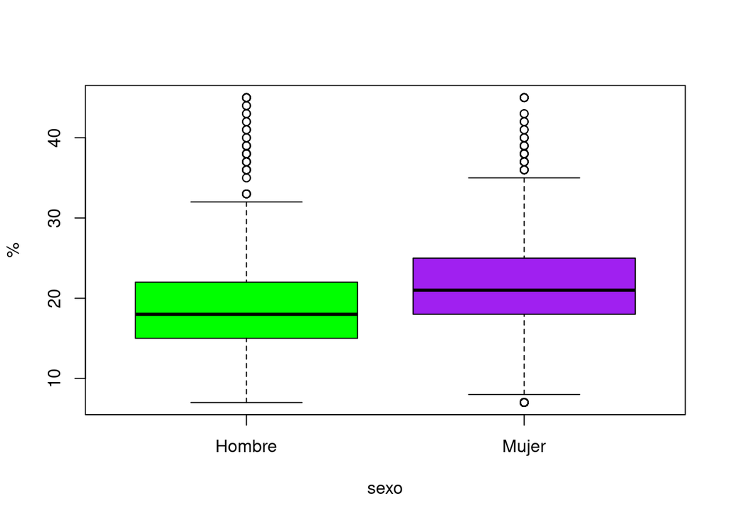

```r
boxplot(porcentajegrasa~sexo,col=c("green","purple"),ylab="%",
outline=TRUE)
```

Los porcentajes de grasa si hacen sentido por que en esa edad es etapa crítica de crecimiento.

## Box plot sin quitar los datos atípicos

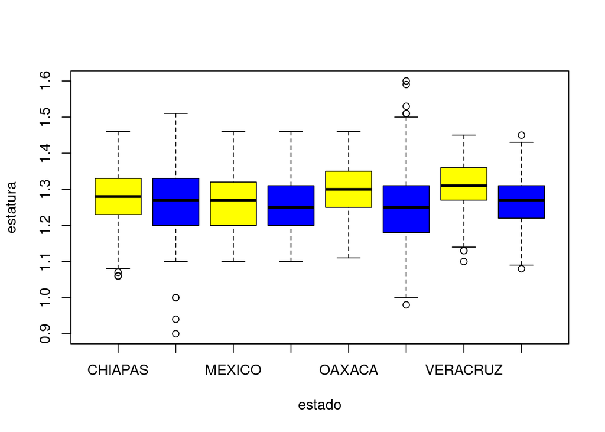

```r
boxplot(estatura~estado,col=c("yellow","blue"))
```

## Boxplot quitando los datos atípicos

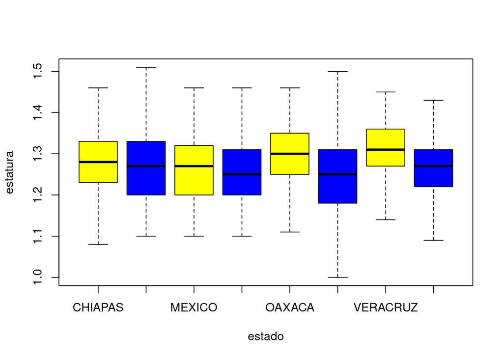

```r
boxplot(estatura~estado,col=c("yellow","blue"), outline=FALSE)
```

Al ver la relación de altura, podemos ver una tendendia central a través de tantos datos que pueden variar mucho.

## Deciles

```r
quantile(cintura, prob=seq(0, 1, length = 11))
```

```
##   0%  10%  20%  30%  40%  50%  60%  70%  80%  90% 100%
##    7   51   54   56   57   59   61   63   67   72  100
```

## Intervalos

Crear un vector con los intervalos

```r
intervalo =c(1,54,57,61,67,100)
```

## Crear el mosaico

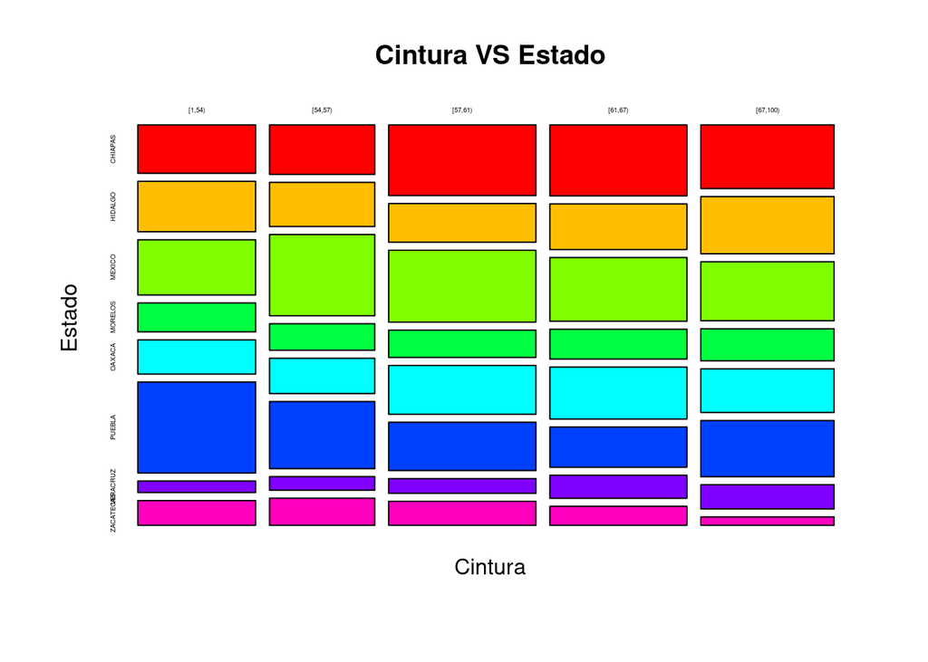

```r
relcintura=cut(dftf$cintura,intervalo,right = FALSE)
mosaicplot(~relcintura+dftf$estado, main = "Cintura VS Estado", color=rainbow(8),
xlab= "Cintura", ylab="Estado", cex.axis=0.3)
```

## Histograma

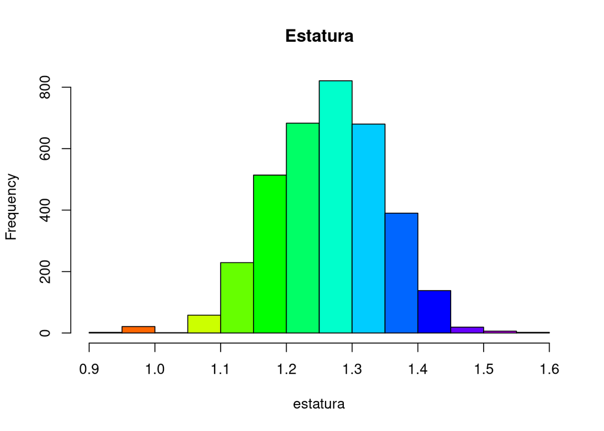

```r
hist(estatura, main = "Estatura", col = rainbow(15))
```

Con solo ver el histograma se llega la conclusión de que la moda esta un poco antes de 1.3 metros

## Sacando media y mediana de la estatura

```r
mean(estatura)
```

```
## [1] 1.270446
```

```r
median(estatura)
```

```
## [1] 1.27
```

El cesgo al que se llega es que se pueden ver tendencias, y es una referencia bastante sólida e incluso tomando en cuenta los datos atípicos siempre habráuna relación. Y que en este caso nuestra moda mediana y media estan extremadamente cerca una del otro, y eso significa que es simétrica.

## Histograma peso

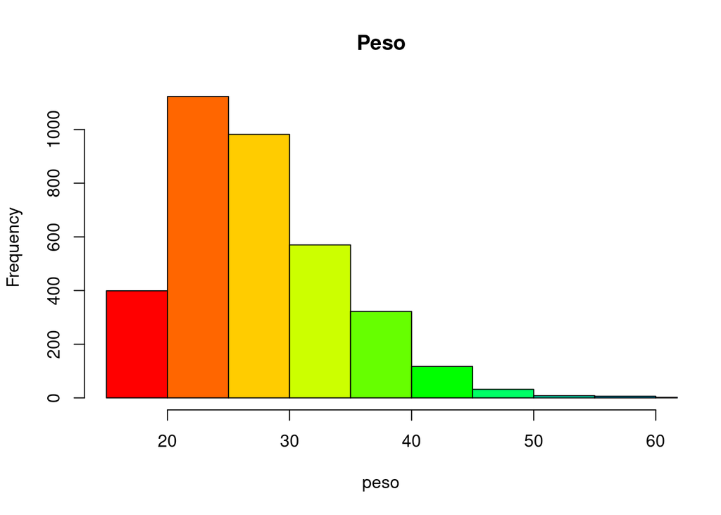

```r
hist(peso, main = "Peso", col = rainbow(15), xlim =c(15,60))
```

```r
range(peso)
```

```
## [1] 15 80
```

```r
seq(15, 50, by=5)
```

```
## [1] 15 20 25 30 35 40 45 50
```

## Intervalo mas pequeño de peso

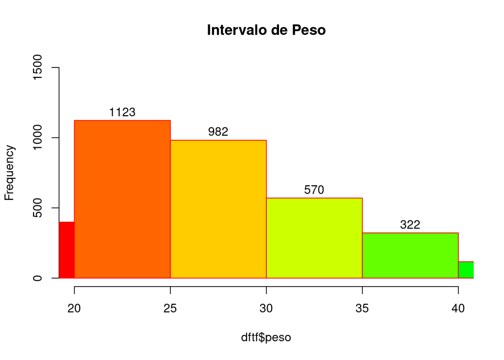

```r
hist(dftf$peso, main = "Intervalo de Peso",
     breaks=c(15,20,25,30,35,40,45,50,55,60,65,70,75,80),
     xlim=c(20,40),ylim =c(0,1500), freq=TRUE,
border="red",col = rainbow(15),labels=TRUE)
```

## Obteniendo la moda media y mediana

```r
mean(dftf$peso)
```

```
## [1] 27.79512
```

```r
median(dftf$peso)
```

```
## [1] 27
```

## La moda la sacaré de manera gráfica

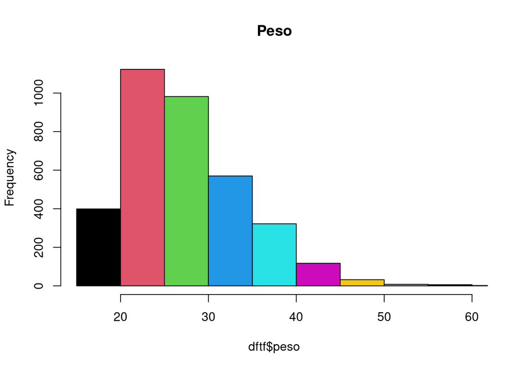

```r
hist(dftf$peso, main = "Peso",col = 1:8, xlim =c(15,60))
```

Viendo la gráfica la moda está en el intervalo de [20,25). Se puede notar que otra fvez la media y mediana están de la mano, pero en ese caso la moda está un poco más separada y es asimétrica a la derecha.

## Ovija

Obtenemos la frecuencia acumulada

```r
intervalopeso = seq(0,80, by=5)
pesointer = cut(dftf$peso, intervalopeso, right=FALSE, dig.lab=5)
p<- table(pesointer)
FAcum <- cumsum(p)
cbind(FAcum)
```

```
##         FAcum
## [0,5)       0
## [5,10)      0
## [10,15)     0
## [15,20)   230
## [20,25)  1304
## [25,30)  2357
## [30,35)  3008
## [35,40)  3349
## [40,45)  3506
## [45,50)  3540
## [50,55)  3553
## [55,60)  3559
## [60,65)  3560
## [65,70)  3562
## [70,75)  3563
## [75,80)  3563
```

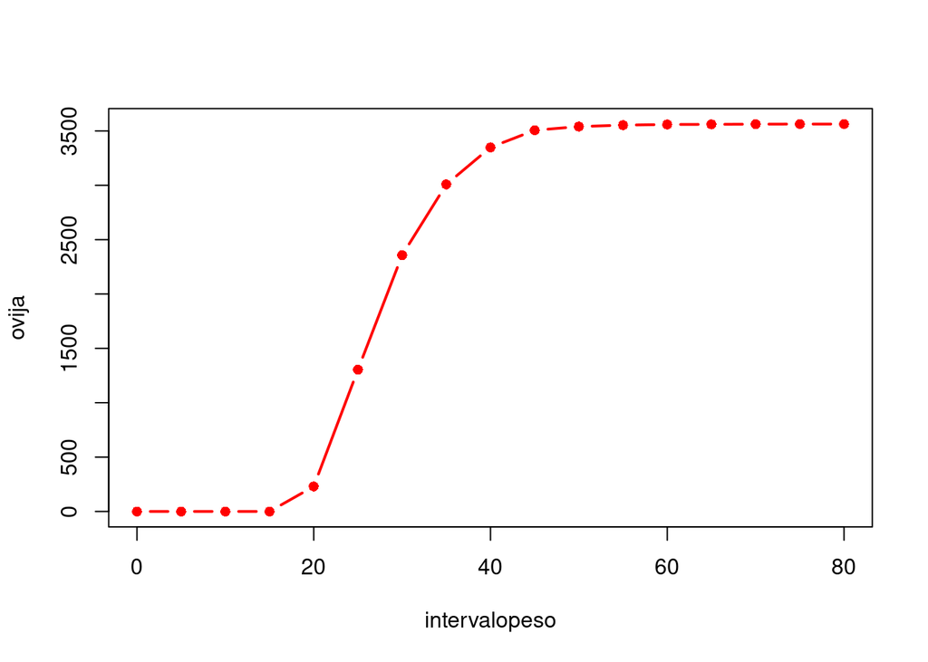

```r
ovija <- c(0,FAcum)
plot(intervalopeso, type="p", ovija, pch=16, col="red")
lines(intervalopeso, ovija, type = "c", lwd=2, col="red")
```

## Promedio de cintura por edad

```r
tapply(dftf$cintura,dftf$edad,mean)
```

```
##        6        7        8        9
## 55.07093 57.53295 60.16882 62.46604
```

## Desviación estándar

```r
tapply(dftf$cintura,dftf$edad,sd)
```

```
##         6         7         8         9
##  9.429488  9.483788  9.475578 10.086453
```

## Sacando el coef de variación cintura por edad

```r
sd(tapply(dftf$cintura,dftf$edad,mean))/mean(tapply(dftf$cintura,dftf$edad,sd))*100
```

```
## [1] 33.32462
```

## Repitiendo el proceso para peso y edad

Primero promedio entre peso por edad

```r
tapply(dftf$peso,dftf$edad,mean)
```

```
##        6        7        8        9
## 22.14597 24.63663 28.10432 31.82202
```

## Desviación estándar para peso por edad

```r
tapply(dftf$peso,dftf$edad,sd)
```

```
##        6        7        8        9
## 5.533261 4.787244 5.813280 6.313670
```

## Coeficiente de variación peso por edad

```r
sd(tapply(dftf$peso,dftf$edad,mean))/mean(tapply(dftf$peso,dftf$edad,sd))*100
```

```
## [1] 75.04047
```

## Diagrama de dispersión Peso por Edad

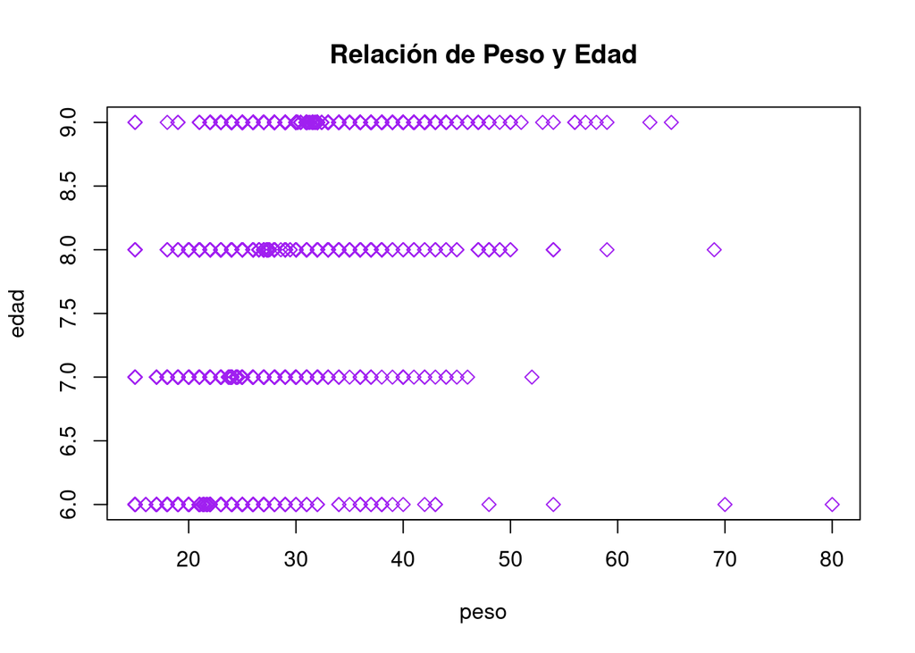

```r
plot(peso,edad,pch=5,col="Purple")
title("Relación de Peso y Edad")
```

## Diagrama de dispersión Estatura por Edad

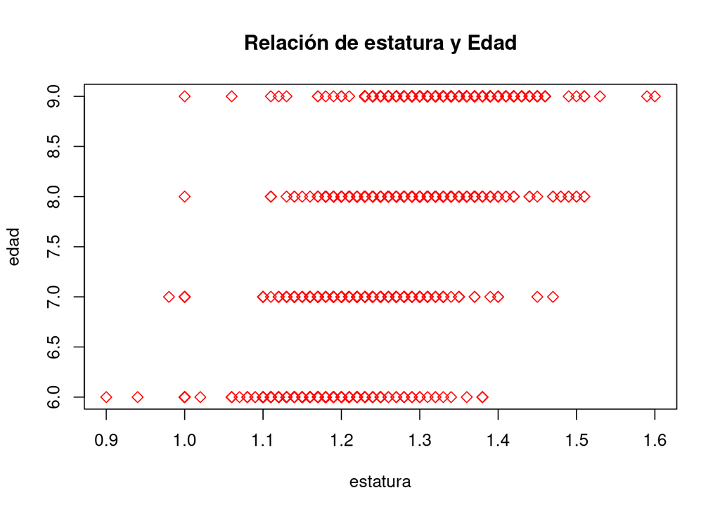

```r
plot(estatura,edad,pch=5,col="Red")
title("Relación de estatura y Edad")
```

## Diagrama de dispersión IMC por Edad

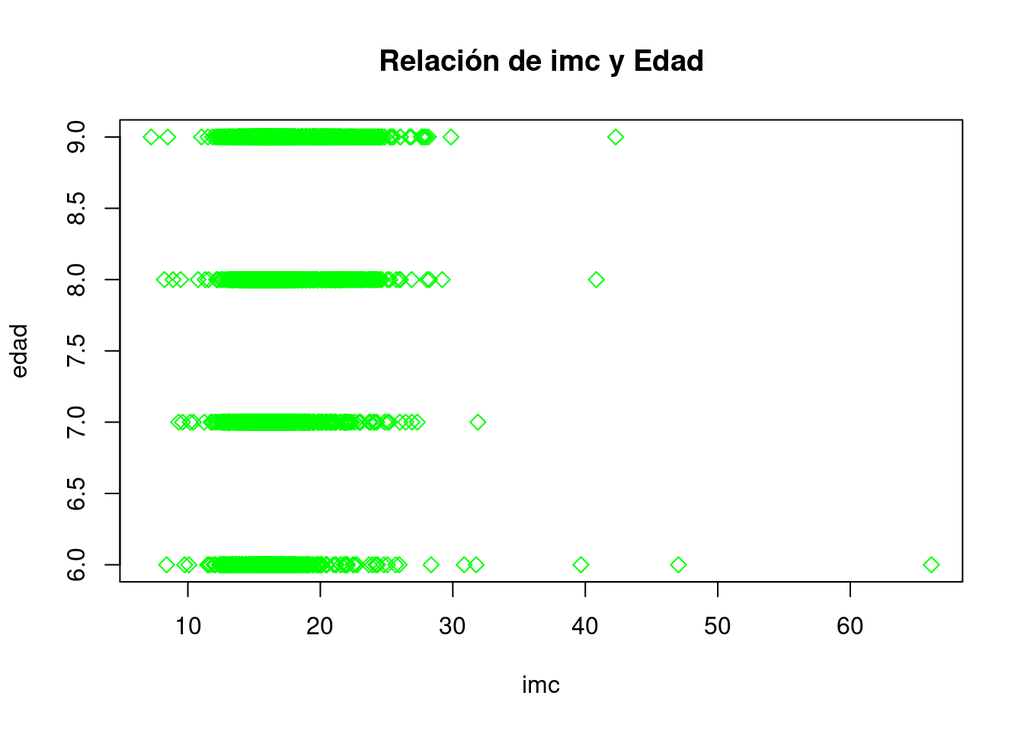

```r
plot(imc,edad,pch=5,col="Green")
title("Relación de imc y Edad")
```

## Haciendo nuevos dataframes con edad de 7 y 8

```r
sieteH =data.frame(estado[sexo=="Hombre" & edad==7],imc[sexo=="Hombre" & edad==7])
sieteM =data.frame(estado[sexo=="Mujer" & edad==7],imc[sexo=="Mujer" & edad==7])
ochoH =data.frame(estado[sexo=="Hombre" & edad==8],imc[sexo=="Hombre" & edad==8])
ochoM =data.frame(estado[sexo=="Mujer" & edad==8],imc[sexo=="Mujer" & edad==8])
```

## Obteniendo el boxplot de imc por estado de dataframe

#### Hombre edad 7

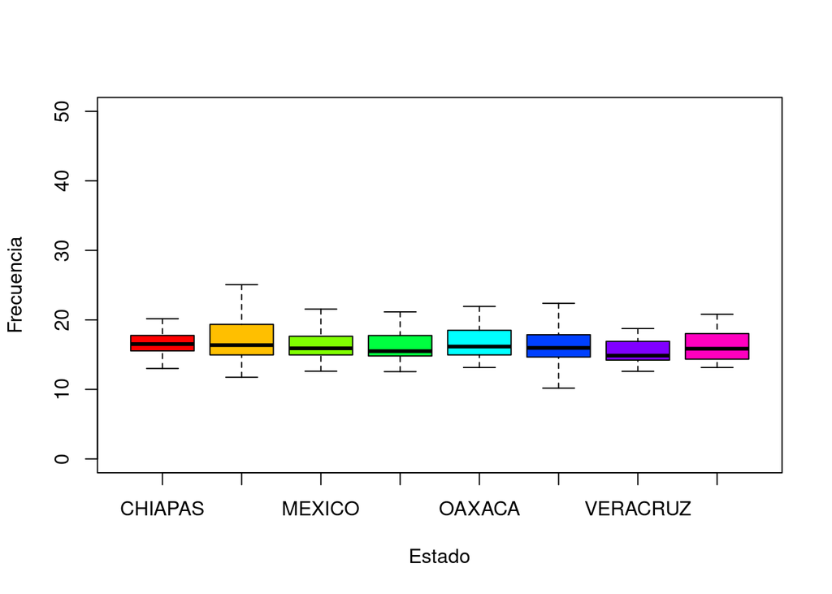

```r
boxplot(sieteH$imc.sexo.....Hombre....edad....7. ~sieteH$estado.sexo.....Hombre....edad....7.,col=rainbow(8), outline=FALSE, ylim =c(0,50),xlab="Estado", ylab = "Frecuencia")
```

#### Mujer edad 7

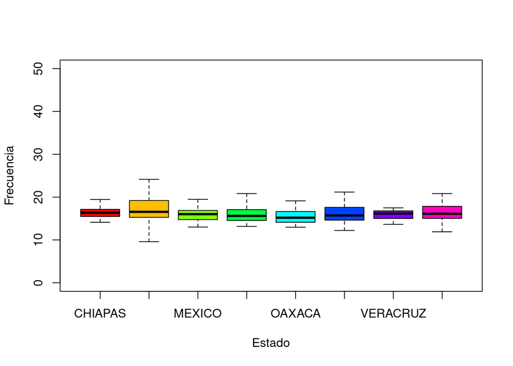

```r
boxplot(sieteM$imc.sexo.....Mujer....edad....7. ~sieteM$estado.sexo.....Mujer....edad....7.,col=rainbow(8), outline=FALSE , ylim =c(0,50),xlab="Estado", ylab = "Frecuencia")
```

#### Hombre edad 8

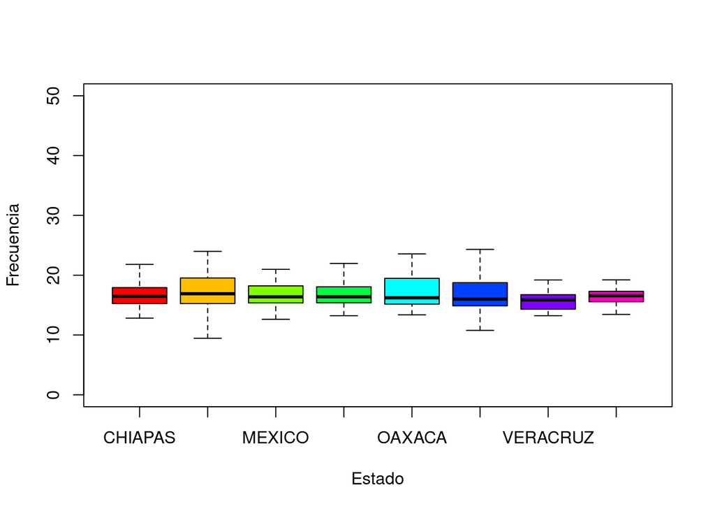

```r
boxplot(ochoH$imc.sexo.....Hombre....edad....8. ~ochoH$estado.sexo.....Hombre....edad....8.,col=rainbow(8), outline=FALSE, ylim =c(0,50),xlab="Estado", ylab = "Frecuencia")
```

#### Mujer edad 8

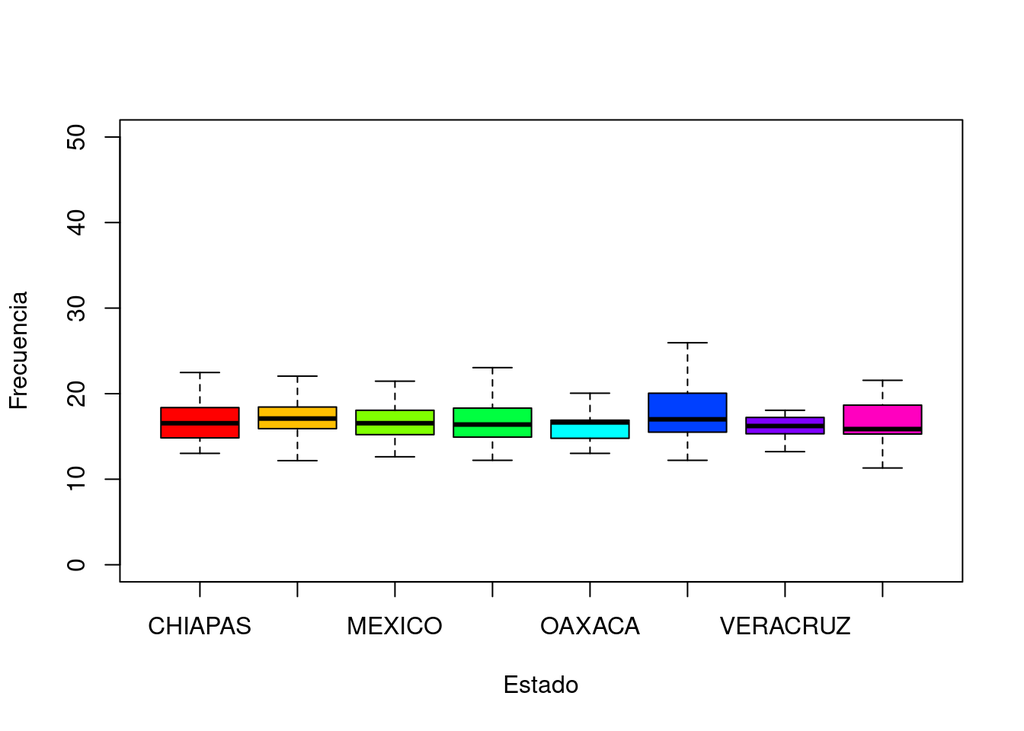

```r
boxplot(ochoM$imc.sexo.....Mujer....edad....8. ~ochoM$estado.sexo.....Mujer....edad....8.,col=rainbow(8), outline=FALSE, ylim =c(0,50),xlab="Estado", ylab = "Frecuencia")
```

## Creando los intervalos para la edad y sexo elegidos, con base a las tablas de la OMS

Tabulacion cruzada de estado por Intervalo 10M

## Intervalos IMC

```r
intervalo7H=c(0,12.2,13.0,14.1,16.9,18.9,50)
intervalo8M=c(0,11.8,12.6,13.8,17.2,19.7,50)
```

## Historiogramas específicos

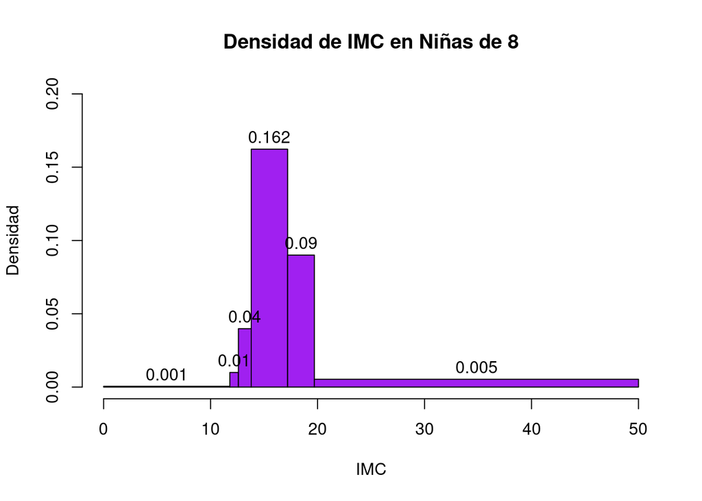

```r
hist(ochoM$imc, breaks=intervalo8M,labels=TRUE,col=c("purple"),xlab = "IMC",ylab = "Densidad",main="Densidad de IMC en Niñas de 8",ylim =c(0,.20))
```

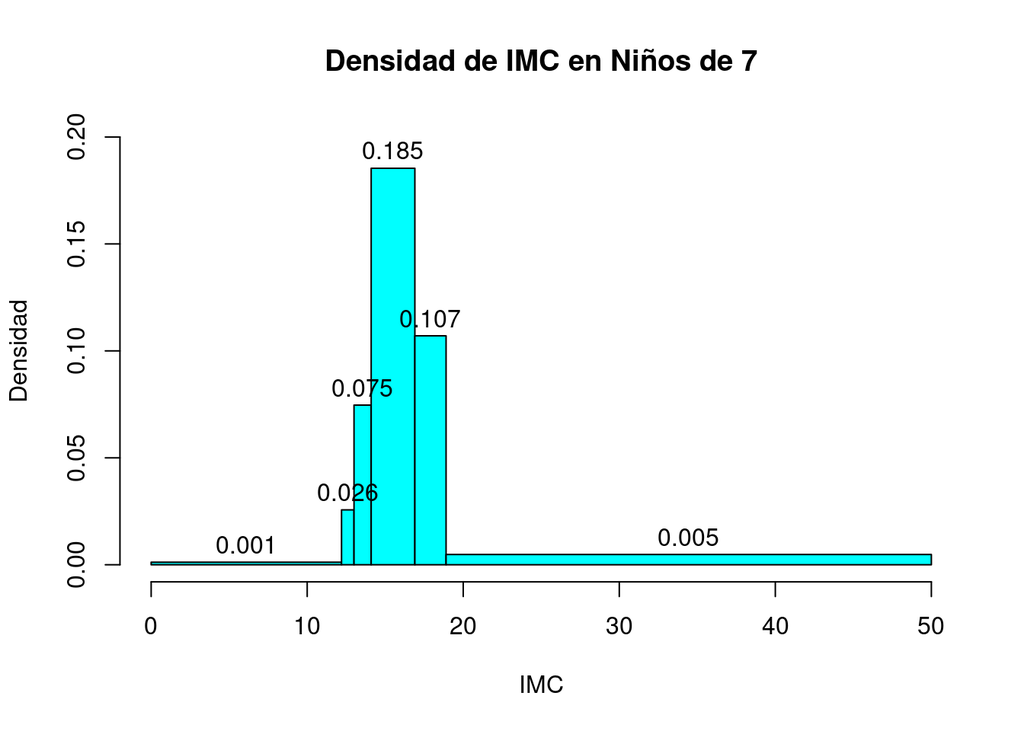

```r
hist(sieteH$imc, breaks=intervalo7H,labels=TRUE,col=c("cyan"),xlab = "IMC",ylab = "Densidad",main="Densidad de IMC en Niños de 7",ylim =c(0,.20))
```

## Tabulación cruzada de estado y IMC

```r
table1=table(ochoM$estado,cut(ochoM$imc,intervalo8M))
table1
```

```
##
##             (0,11.8] (11.8,12.6] (12.6,13.8] (13.8,17.2] (17.2,19.7] (19.7,50]
##   CHIAPAS          0           0           6          68          30        14
##   HIDALGO          2           1           2          26          17        13
##   MEXICO           0           0           1          43          16         6
##   MORELOS          0           1           3          31          15         7
##   OAXACA           0           0           4          25           5         3
##   PUEBLA           0           2           5          55          23        33
##   VERACRUZ         0           0           2          10           3         1
##   ZACATECAS        1           0           1          19           4         4
```

```r
table2=table(sieteH$estado,cut(sieteH$imc,intervalo7H))
table2
```

```
##
##             (0,12.2] (12.2,13] (13,14.1] (14.1,16.9] (16.9,18.9] (18.9,50]
##   CHIAPAS          2         0         2          20          11         3
##   HIDALGO          1         2         4          19           8        14
##   MEXICO           0         1         4          49          21         7
##   MORELOS          0         1         3          19           8         5
##   OAXACA           0         0         5          19           8         5
##   PUEBLA           2         1         6          35          10        13
##   VERACRUZ         0         2         0           6           3         0
##   ZACATECAS        0         0         4          10           4         4
```

## Barras apiladas

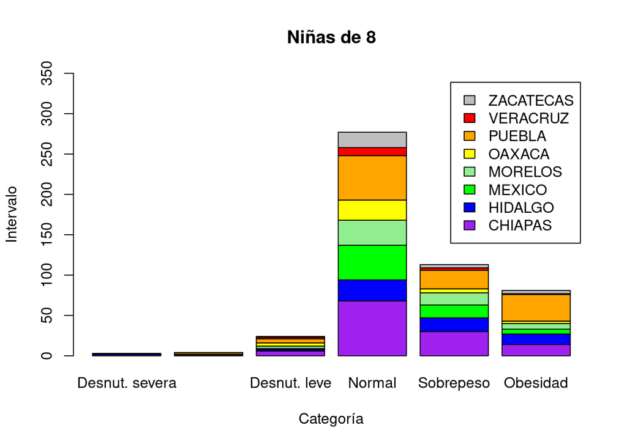

```r
edodesnu=c("Desnut. severa","Desnut. moderada","Desnut. leve","Normal","Sobrepeso","Obesidad")
barplot(table1, names.arg=edodesnu,legend=rownames(table1),ylim=c(0,350),col=c("purple","blue","green","lightgreen","yellow","orange","red","gray"),xlab = "Categoría",ylab = "Intervalo",main="Niñas de 8")
```

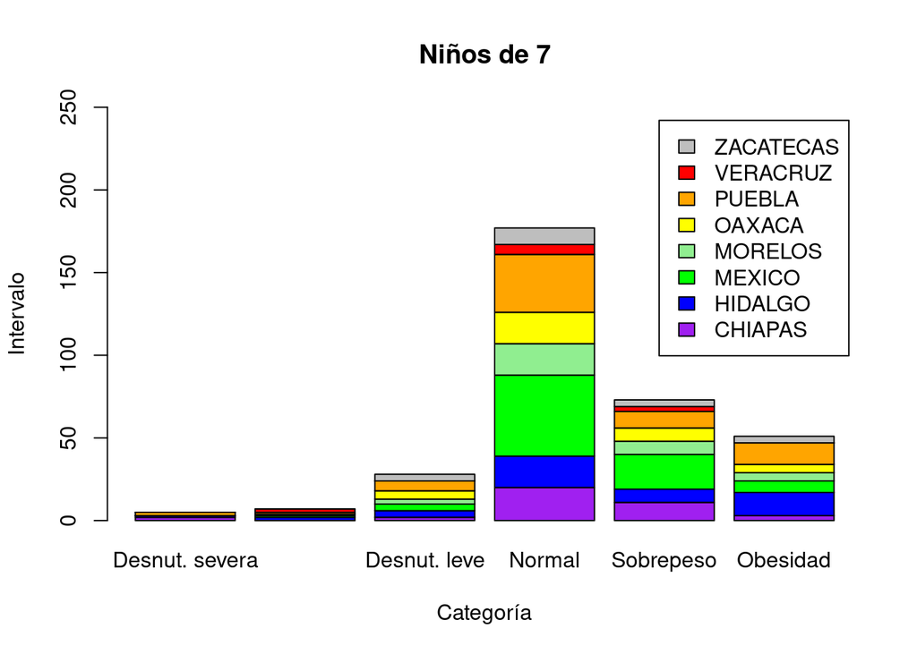

```r
barplot(table2, names.arg=edodesnu,legend=rownames(table2),ylim=c(0,250),col=c("purple","blue","green","lightgreen","yellow","orange","red","gray"),xlab = "Categoría",ylab = "Intervalo",main="Niños de 7")
```

De estos gráficos se puede ver una tendencia muy sana, ya que la moda es en lo normal, y con una inclunacion hacia el sobre peso que no es tan sano, pero no afecta tanto como la desnutrición, las muestras se ven en los edos. Mas grandes y son prueba de esta tendencia general.

Por otra parte tanto las niñas y niños tienen una grave tendencia al sobrepeso, así que tiene que haber un causante, ya que llega casi a la mitad de la cantidad de normales.

# Repitiendo el proceso.

## Historiogramas específicos 2

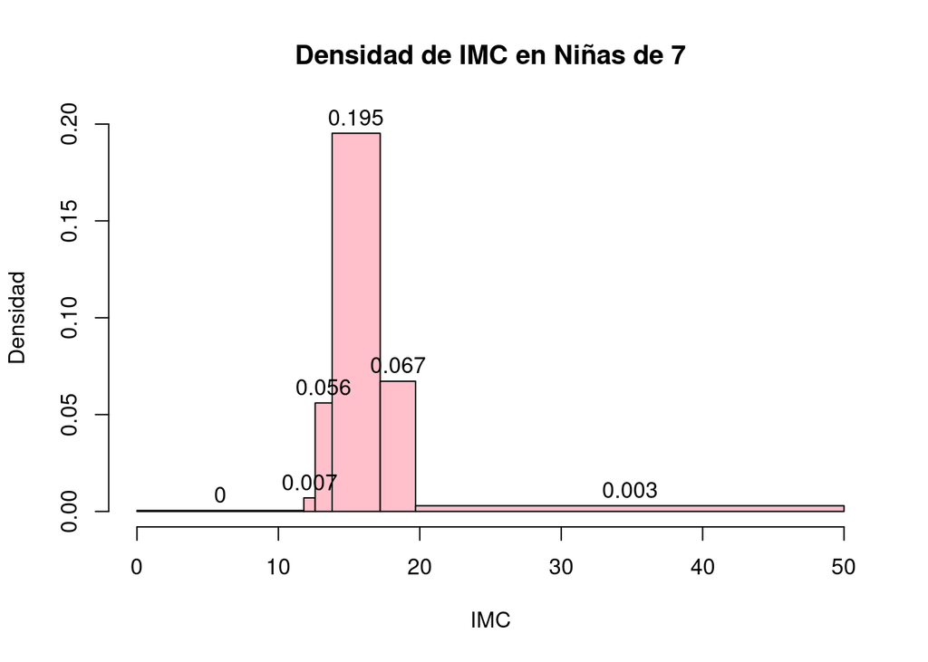

```r
hist(sieteM$imc, breaks=intervalo8M,labels=TRUE,col=c("pink"),xlab = "IMC",ylab = "Densidad",main="Densidad de IMC en Niñas de 7", ylim =c(0,.20))
```

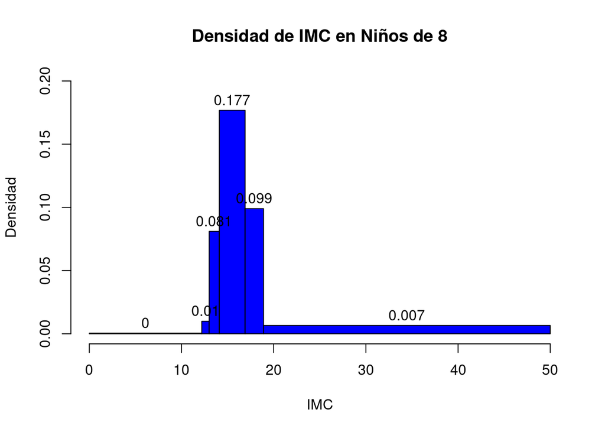

```r
hist(ochoH$imc, breaks=intervalo7H,labels=TRUE,col=c("blue"),xlab = "IMC",ylab = "Densidad",main="Densidad de IMC en Niños de 8", ylim =c(0,.20))
```

## Tabulación cruzada de estado y IMC

```r
table1=table(sieteM$estado,cut(sieteM$imc,intervalo8M))
table1
```

```
##
##             (0,11.8] (11.8,12.6] (12.6,13.8] (13.8,17.2] (17.2,19.7] (19.7,50]
##   CHIAPAS          0           0           1          19           6         1
##   HIDALGO          2           0           1          29          12        12
##   MEXICO           0           0           4          65           9         2
##   MORELOS          0           0           5          27           8         1
##   OAXACA           0           0           3          14           3         2
##   PUEBLA           0           1           7          61          13        13
##   VERACRUZ         0           0           1           7           3         0
##   ZACATECAS        0           1           2          15           6         1
```

```r
table2=table(ochoH$estado,cut(ochoH$imc,intervalo7H))
table2
```

```
##
##             (0,12.2] (12.2,13] (13,14.1] (14.1,16.9] (16.9,18.9] (18.9,50]
##   CHIAPAS          0         1        14          55          23        19
##   HIDALGO          2         1         5          23          12        16
##   MEXICO           0         1         7          54          20        15
##   MORELOS          0         0         3          22          11         9
##   OAXACA           0         0         2          30           5        14
##   PUEBLA           1         1        11          41          20        23
##   VERACRUZ         0         0         2           8           0         3
##   ZACATECAS        0         0         1          17           9         4
```

## Barras apiladas

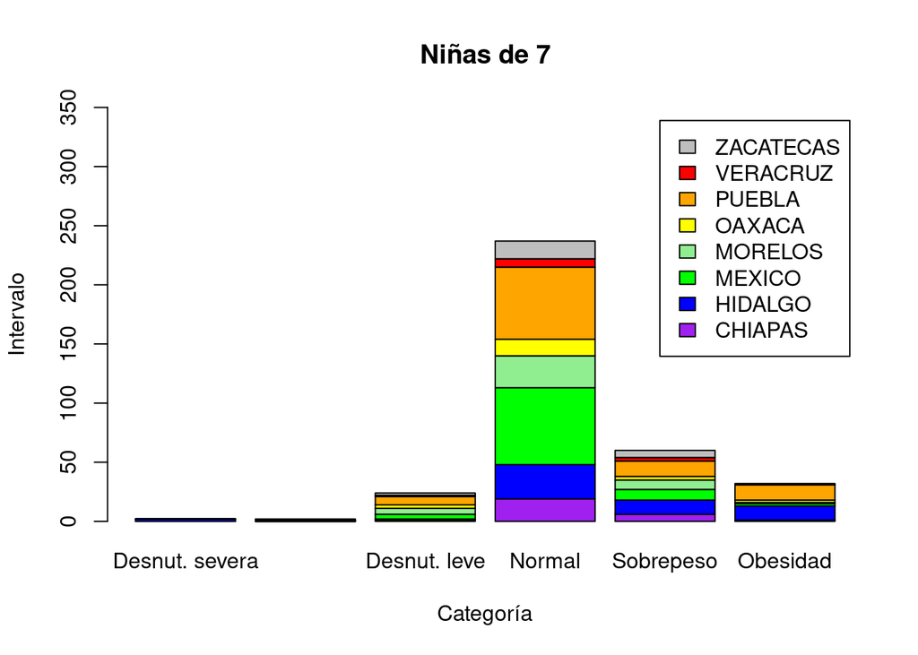

```r
edodesnu=c("Desnut. severa","Desnut. moderada","Desnut. leve","Normal","Sobrepeso","Obesidad")
barplot(table1, names.arg=edodesnu,legend=rownames(table1),ylim=c(0,350),col=c("purple","blue","green","lightgreen","yellow","orange","red","gray"),xlab = "Categoría",ylab = "Intervalo",main="Niñas de 7")
```

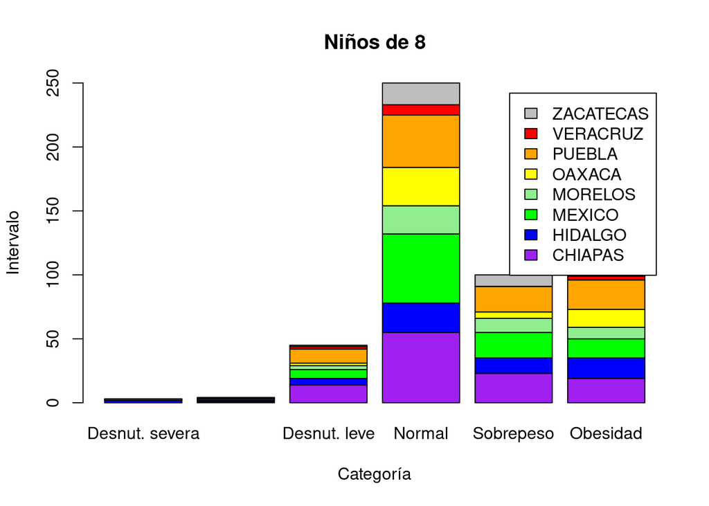

```r
barplot(table2, names.arg=edodesnu,legend=rownames(table2),ylim=c(0,250),col=c("purple","blue","green","lightgreen","yellow","orange","red","gray"),xlab = "Categoría",ylab = "Intervalo",main="Niños de 8")
```

# Genera otros 3 estadísticos o gráficos que enriquezcan la investigación

```r
ls(mediciones)
```

```
## [1] "cintura"         "edad"            "estado"          "estatura"
## [5] "imc"             "peso"            "porcentajegrasa" "sexo"
```

## Mujeres solo con IMC a los 6 años

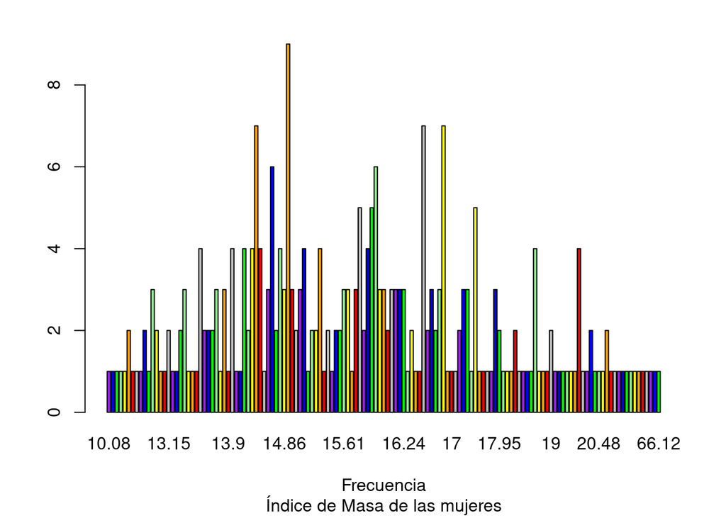

```r
imcmuj =data.frame(imc[sexo=="Mujer" & edad==6])
mujmc=table(imcmuj)
barplot(mujmc, sub = "Índice de Masa de las mujeres", yli =c(0,08),
col=c("purple","blue","green","lightgreen","yellow","orange","red","gray"), xlab="Frecuencia")
```

## Hombres solo con IMC a los 6 años

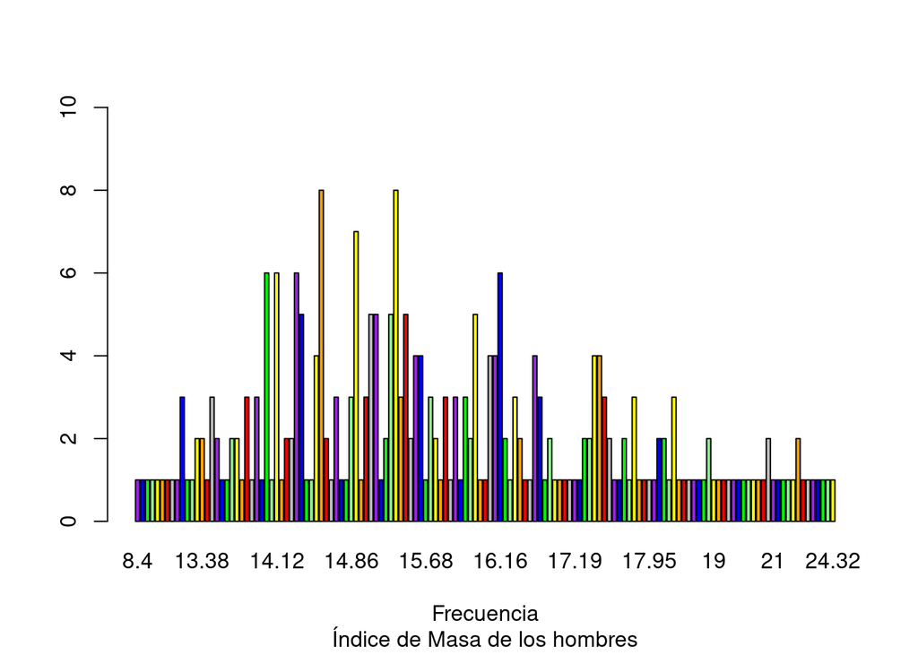

```r
imchom=data.frame(imc[sexo=="Hombre"& edad==6])
hommc=table(imchom)
barplot(hommc, sub = "Índice de Masa de los hombres", yli =c(0,10),
col=c("purple","blue","green","lightgreen","yellow","orange","red","gray"), xlab="Frecuencia")
```

## Sacando la grafica de IMC de MEXICO con Mujeres y de 6 años

[figure not shown]

```r
meximc =data.frame(imc[estado=="MEXICO" & edad==6 & sexo=="Mujer"])
imcmx=table(meximc)
barplot(imcmx,sub = "Índice de Masa de CDMX",
col=rainbow(9))
```